# Module1 Search for cancer hallmarks

Patipark Kueanjinda

October 10, 2018; last modified on June 9, 2020

Call necessary R packages.

Download all data tables.

Data pre-processing steps Removel white space in the columns in GR50 table

Modify names of CCA cell lines obtained from CSV table to meet conventional names

To compare expression level, we divided cell lines into 2 groups by their response to comprehensive drugs (CCA1 and CCA2). Average (log2TMP) of gene expression level per gene per cell line would be calculated and duplicates were eliminated. Genes with average expression levels less than 50th quantile were removed.

Number of genes post-processing

```
[1] 13390
```

In general, gene expression levels are reported as the fold-change of expression level of cases compared to controls. In this study, however, the controls were defined as median expression level across all CCA cell lines. (Normal cholangiocyte gene expression data were not included.) Hence, fold-change expression level of genes in each cell line was calculated from comparison of the expression level of the gene of a cell line to median expression level of the same gene across all cell lines.

Now, we converted from log2TPM to median-centered expression level.

In the next step, we wanted to use GSEA for pathway analysis. In general, GSEA requires input data including gene expression levels from A compared to B. Thus, we defined A as CCA1 group (n = 6) and B as CCA2 group (n = 9), according to analysis in Figure 3A. Because median value is less affected by ouliers and represented nearly true value of the population, we calculated median expression level of genes in each subtype and converted to fold-change expression level of genes (FC = median A/ median B).

Because we were also interested in cell line-organ similarity, we created organ similarity category.

| Gene | Cell | Cell.subgroup | Org.subgroup | TPM.m | TPM.z |
| --- | --- | --- | --- | --- | --- |
| A1BG-AS1 | HuCCA-1 | 1 | 2 | 3.252154 | 0.0000000 |
| A1BG-AS1 | HuCCT-1 | 2 | 2 | 2.781136 | -0.4710184 |
| A1BG-AS1 | HuH-28 | 2 | 1 | 4.114953 | 0.8627984 |
| A1BG-AS1 | KKK-D068 | 2 | 1 | 5.253926 | 2.0017716 |
| A1BG-AS1 | KKK-D131 | 2 | 2 | 3.237456 | -0.0146987 |
| A1BG-AS1 | KKK-D138 | 1 | 1 | 5.168961 | 1.9168072 |

Drug sensitivity determination

GR50 values (in log10 format from Figure 2A) were used determine whether the cell lines were sensitive or resistant to a particular drug. Regardless of distribution of GR50, median GR50 of the population was calculated for a particular drug.

|  | A443654 | Abemaciclib | Afatinib | Azacitidine | AZD4547 | AZD8055 | BAY11-7082 | BEZ-235 | BGJ398-Nov | BGJ398-NVP | Birinapant | Bleomycin | Bosutinib | Bupalisib | BYL719 | Caffeic APE | CDK1_2III | Celastrol | Cisplatin | Crizotinib | Dasatinib | Decitabine | Dovitinib | Doxorubicin | Epirubicin | Erlotinib | Etoposide | Fedratinib | FiveFU | … |
| --- | --- | --- | --- | --- | --- | --- | --- | --- | --- | --- | --- | --- | --- | --- | --- | --- | --- | --- | --- | --- | --- | --- | --- | --- | --- | --- | --- | --- | --- | --- |
| HuCCA-1 | -0.08471844 | 0.09970544 | -1.580546317 | -0.424912112 | 0.1443429 | -0.04110633 | -0.52870317 | 0.5791190 | -0.031590573 | 0.22869328 | 0.1261442 | -0.67050940 | -0.76326617 | -0.34521384 | -0.5356137 | -0.147338963 | -0.047738418 | -0.28406579 | -0.2160973 | 0.01253472 | 0.0000000 | 0.01985513 | 0.05629776 | -0.6569056 | 0.20890577 | -1.557111 | 0.07808437 | 0.30324116 | 0.60367082 | … |
| HuCCT-1 | -0.12485923 | -0.28219626 | 0.099073049 | -0.003815867 | -0.2076429 | 0.02057300 | -0.03052439 | -0.2897511 | 0.055973450 | 0.02633943 | 0.1261442 | 0.02745245 | 0.02301923 | -0.03250222 | 0.1120536 | 0.005362128 | -0.008170114 | -0.29125068 | 0.3280161 | -0.05287826 | 1.2485167 | 0.01985513 | 0.06458098 | 0.1200332 | -0.08846224 | 0.000000 | 0.00000000 | 0.00000000 | -0.78803316 | … |
| HuH-28 | -0.21826088 | 0.00000000 | -0.220049974 | 0.417714052 | -0.7025543 | 0.60590970 | -0.90267186 | 0.6536778 | -2.565595699 | -0.42930712 | 0.0000000 | 0.25751649 | -0.23972736 | -0.07052852 | -0.3677756 | -0.105729438 | -0.075535302 | -0.22587735 | -0.3954646 | -0.15581925 | -0.5215854 | 0.01985513 | -0.54825227 | -0.6758974 | -0.71015681 | 0.000000 | -0.74611359 | -0.25191821 | 0.41226160 | … |
| KKK-D068 | 0.06146075 | 0.31385137 | 0.019284925 | 0.334929068 | -0.1065388 | 0.25131196 | 0.13228081 | 0.0000000 | 0.004771483 | -0.17348507 | -2.8841557 | -0.44548120 | 0.26080071 | 0.02044040 | 0.1120536 | 0.000000000 | 0.122302898 | 0.04893774 | 0.4340101 | -0.44502635 | 0.7249486 | -0.27885809 | 0.00000000 | -0.5096274 | 0.09399944 | 0.000000 | 0.04263468 | -0.09317702 | -0.24271761 | … |
| KKK-D131 | 0.04873599 | -0.33107142 | 0.219429466 | 0.325513578 | 0.1443429 | -0.33387692 | 0.40551585 | -0.6585159 | 0.269185662 | 0.28203786 | -0.1545398 | 0.00000000 | 0.16691016 | 0.17532647 | 0.1120536 | 0.005362128 | -0.097232251 | -0.11453723 | 0.4470057 | 0.10236250 | -0.1696030 | -0.21676328 | -0.31506335 | -0.3043521 | 0.12588667 | 0.000000 | 0.19189865 | 0.07327987 | -0.43482767 | … |
| KKK-D138 | -0.15927398 | -0.45104909 | -0.009997605 | -0.215963738 | -0.9482583 | -0.14426796 | 0.31019120 | -0.3986027 | -1.171717464 | -0.84744652 | 0.1261442 | -0.12395710 | -0.14195784 | 0.01493368 | -0.6296859 | 0.005362128 | 0.094829359 | 0.09259134 | -0.5302891 | -0.11836338 | -0.2980383 | 0.00000000 | -0.31329508 | 0.2386913 | 0.20498368 | 0.000000 | 0.54770343 | -0.07040278 | -0.03680768 | … |

As a result, there are 80 drugs remaining for further analysis

```
[1] 80
```

Check n = 0 in subclass in each drug

| Drug | Class | n |
| --- | --- | --- |
| A443654 | R | 8 |
| A443654 | S | 7 |
| Abemaciclib | R | 8 |
| Abemaciclib | S | 7 |
| Afatinib | R | 8 |
| Afatinib | S | 7 |

```
factor(0)
80 Levels: A443654 Abemaciclib Afatinib Azacitidine AZD4547 AZD8055 BAY11-7082 BEZ-235 BGJ398-Nov BGJ398-NVP Birinapant Bleomycin ... Vorinostat
```

We used kernel density estimation to identify cut-off point that separates sensitiveness or resistance group of cell lines.

Cut-off points for drug sensitivity estimation were reported as Table S3

Density plots of drug sensitive and drug resistant CCA cell lines using previously calculated cut-off points.

Now put 80 drugs together

|  | Cell | Drug | norm.GR50 | Class.KDE | SubMedianGR50 | Class.MD |
| --- | --- | --- | --- | --- | --- | --- |
| 1 | HuCCA-1 | A443654 | -0.6041538 | S | -0.08471844 | S |
| 2 | HuCCT-1 | A443654 | -0.8340989 | S | -0.12485923 | S |
| 3 | HuH-28 | A443654 | -1.3691472 | S | -0.21826088 | S |
| 4 | KKK-D068 | A443654 | 0.2332289 | R | 0.06146075 | R |
| 5 | KKK-D131 | A443654 | 0.1603355 | R | 0.04873599 | R |
| 6 | KKK-D138 | A443654 | -1.0312427 | S | -0.15927398 | S |

Plot Figure S6D

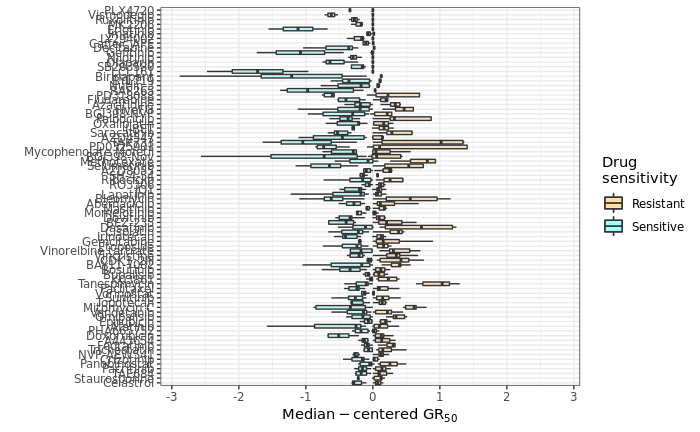

Save figure KDE of all drugs

Next, we asked whether KDE was better or worse than median-centered GR50 approach.

|  | Drug | Accuracy | Kappa | AccuracyLower | AccuracyUpper | AccuracyNull | AccuracyPValue | McnemarPValue | Sensitivity | Specificity | Pos.Pred.Value | Neg.Pred.Value | Precision | Recall | F1 | Prevalence | Detection.Rate | Detection.Prevalence | Balanced.Accuracy |
| --- | --- | --- | --- | --- | --- | --- | --- | --- | --- | --- | --- | --- | --- | --- | --- | --- | --- | --- | --- |
| 1 | A443654 | 1 | 1 | 0.7819806 | 1 | 0.5333333 | 8.034908e-05 | NaN | 1 | 1 | 1 | 1 | 1 | 1 | 1 | 0.4666667 | 0.4666667 | 0.4666667 | 1 |
| 2 | Abemaciclib | 1 | 1 | 0.7819806 | 1 | 0.5333333 | 8.034908e-05 | NaN | 1 | 1 | 1 | 1 | 1 | 1 | 1 | 0.4666667 | 0.4666667 | 0.4666667 | 1 |
| 3 | BEZ-235 | 1 | 1 | 0.7819806 | 1 | 0.5333333 | 8.034908e-05 | NaN | 1 | 1 | 1 | 1 | 1 | 1 | 1 | 0.4666667 | 0.4666667 | 0.4666667 | 1 |
| 4 | Birinapant | 1 | 1 | 0.7819806 | 1 | 0.5333333 | 8.034908e-05 | NaN | 1 | 1 | 1 | 1 | 1 | 1 | 1 | 0.4666667 | 0.4666667 | 0.4666667 | 1 |
| 5 | Bleomycin | 1 | 1 | 0.7819806 | 1 | 0.5333333 | 8.034908e-05 | NaN | 1 | 1 | 1 | 1 | 1 | 1 | 1 | 0.4666667 | 0.4666667 | 0.4666667 | 1 |
| 6 | Bosutinib | 1 | 1 | 0.7819806 | 1 | 0.5333333 | 8.034908e-05 | NaN | 1 | 1 | 1 | 1 | 1 | 1 | 1 | 0.4666667 | 0.4666667 | 0.4666667 | 1 |

Save accuracy table of KDE vs. medican-centered GR50 classification

After successfully classifying cells by drug sensitive, we wanted to add all data together with CCA subtypes and Organ similarity. This data table contained the followings: Cell names, drug names, median-centered GR50, drug sensitivity by KDE, drug sensitivity by CCA subtypes, organ-like status.

|  | Cell | Drug | norm.GR50 | Class.KDE | SubMedianGR50 | Class.MD | CCA.Subgroup | Organ.Subgroup |
| --- | --- | --- | --- | --- | --- | --- | --- | --- |
| 1 | HuCCA-1 | A443654 | -0.6041538 | Sensitive | -0.08471844 | Sensitive | Subgroup 1 | pancreas-like |
| 2 | HuCCT-1 | A443654 | -0.8340989 | Sensitive | -0.12485923 | Sensitive | Subgroup 2 | pancreas-like |
| 3 | HuH-28 | A443654 | -1.3691472 | Sensitive | -0.21826088 | Sensitive | Subgroup 2 | liver-like |
| 4 | KKK-D068 | A443654 | 0.2332289 | Resistant | 0.06146075 | Resistant | Subgroup 2 | liver-like |
| 5 | KKK-D131 | A443654 | 0.1603355 | Resistant | 0.04873599 | Resistant | Subgroup 2 | pancreas-like |
| 6 | KKK-D138 | A443654 | -1.0312427 | Sensitive | -0.15927398 | Sensitive | Subgroup 1 | liver-like |

Save data table for prediction module

Check number of cells in each drug senstivity subgroup identified by KDE

| Drug | Class.KDE | n |
| --- | --- | --- |
| A443654 | Sensitive | 7 |
| A443654 | Resistant | 8 |
| Abemaciclib | Sensitive | 7 |
| Abemaciclib | Resistant | 8 |
| Afatinib | Sensitive | 6 |
| Afatinib | Resistant | 9 |

```
factor(0)
80 Levels: A443654 Abemaciclib Afatinib Azacitidine AZD4547 AZD8055 BAY11-7082 BEZ-235 BGJ398-Nov BGJ398-NVP Birinapant Bleomycin ... Vorinostat
```

Identification of significnat cancer hallmarks using GSEA

We next asked what pathways were enriched in: 1. CCA subtype 1 2. Individual drug sensitive 3. Liver-like 4. Individual cell line compared to whole population

To perform GSEA, we needed to convert from gene expression level (herein log2[TPM]) to fold-change expression level compared to specific the control group. Hence, for each question the control group was: A. CCA subtype 2 B. Individual drug resistant C. Pancreas-like D. median expression levels of genes across all cell lines

Calculate fold-change expression level of drug sensitive over drug resistant group (2-B) We needed a) log2TMP expression level data and b) individual drug response data.

Calculate fold-change expression level of CCA1 over CCA2 group (1-A) We needed a) log2TMP expression level data and b) CCA subtype identification

Calculate fold-change expression level of liver-like over pancreas-like group (3-C) We needed a) log2TMP expression level data and b) organ similarity identification

Calculate fold-change expression level of individual cells over population (4-D) We needed a) log2TMP expression level data and b) TPM.z

Save fold-change of expression levels data table

Next step, we convert gene names to ENTREZ id for gene annotation. This function require ‘clusterProfiler’ R package.

```
6.3% of input gene IDs are fail to map...'select()' returned 1:many mapping between keys and columns
```

Newest updated MSigDB was on 13 October 2018. Downloaded MSigDBv6_2.zip

Perform GSEA using ‘DOSE’ R package

We define inputs for GSEA.

Run GSEA using customized function and defined parameters.

[output not shown]

[output cut: 84 more lines]

|  | ID | Description | Cell | setSize | enrichmentScore | NES | pvalue | p.adjust | qvalues | rank | leading_edge | core_enrichment |
| --- | --- | --- | --- | --- | --- | --- | --- | --- | --- | --- | --- | --- |
| 1 | HALLMARK_EPITHELIAL_MESENCHYMAL_TRANSITION | HALLMARK_EPITHELIAL_MESENCHYMAL_TRANSITION | A443654_S.R | 142 | 0.6357544 | 2.589956 | 0.001808318 | 0.01680672 | 0.01167625 | 1224 | tags=47%, list=10%, signal=43% | IGFBP2/EDIL3/TPM1/TPM2/CDH2/BASP1/COL6A2/HTRA1/VIM/COL5A2/CO…… |
| 2 | HALLMARK_UV_RESPONSE_DN | HALLMARK_UV_RESPONSE_DN | A443654_S.R | 120 | 0.5019669 | 1.999112 | 0.001841621 | 0.01680672 | 0.01167625 | 1938 | tags=33%, list=15%, signal=28% | SDC2/EFEMP1/COL5A2/COL3A1/SERPINE1/PMP22/PLCB4/MAP1B/LAMC1/A…… |
| 3 | HALLMARK_ANGIOGENESIS | HALLMARK_ANGIOGENESIS | A443654_S.R | 23 | 0.6532721 | 1.849909 | 0.001912046 | 0.01680672 | 0.01167625 | 1180 | tags=52%, list=9%, signal=47% | COL5A2/COL3A1/FSTL1/FGFR1/ITGAV/S100A4/VTN/PGLYRP1/TIMP1/VCAN/NRP1/APP |
| 4 | HALLMARK_KRAS_SIGNALING_UP | HALLMARK_KRAS_SIGNALING_UP | A443654_S.R | 111 | -0.3910017 | -1.570094 | 0.002173913 | 0.01680672 | 0.01167625 | 927 | tags=22%, list=7%, signal=20% | PLAT/MALL/TRIB2/TNFAIP3/HBEGF/AKAP12/TSPAN1/BMP2/SEMA3B/ITGA2/F2RL1/PLAU/ANO1/EREG/ITGBL1/KLF4/PTGS2/MPZL2/GALNT3/ADAM8/JUP/MAP7/PLEK2/LCP1 |
| 5 | HALLMARK_ESTROGEN_RESPONSE_LATE | HALLMARK_ESTROGEN_RESPONSE_LATE | A443654_S.R | 149 | -0.4761503 | -1.999913 | 0.002267574 | 0.01680672 | 0.01167625 | 719 | tags=24%, list=6%, signal=23% | XBP1/CHPT1/GJB3/SLC27A2/MEST/KRT13/FOS/AGR2/FOXC1/SEMA3B/HOM…… |
| 6 | HALLMARK_ESTROGEN_RESPONSE_EARLY | HALLMARK_ESTROGEN_RESPONSE_EARLY | A443654_S.R | 159 | -0.4920172 | -2.078268 | 0.002304147 | 0.01680672 | 0.01167625 | 1980 | tags=35%, list=16%, signal=30% | SLC1A4/MYC/SIAH2/TPD52L1/ELF3/SLC37A1/KRT8/CELSR1/SEC14L2/TO…… |

Save data.

Data visualization

Volcano plot displaying enriched pathways only found in Subtype_1.2

[figure not shown]

Save volcano plot for Figure 4Aorg